# RSCx Mixed Analysis

Lorenz Oehler

2023-10-05

# Introduction

This document is about the Immunohistochemistry that was used to deternine the expression of CNPase, which is an enzym which is primarily expressed in oligodendrocytes and is responsible for producing myelin sheaths around axons.

On of the obstacles I had to face was the use of two different Microskops. Thus I decided to use the standardized z-Score for both of the Microskopes for the plots.

I will first startwith a descriptive analysis an plotting the Plot section. Later I will do a statistical analysis.

## AFIU explained

AFIU (Arbitrary Flourescence Intensity Unit) is an acronym I used to describe the flourescence Intensity, which is our measurement for the the expresssion of CNPase.

The basis of the Measurement is the CTCF (El-Sharkawey (2016)), but because were not interested in the flourescence Intensity of a singel cell, we devidid the value of the CTCF by the area, which was selected in imagej. The special aspect of the CTCF is, that it takes the background intensity into account.

This is the Formula of the CTCF:

$IntegratedDenisty - (AreaOfSelectedCell \times MeanFlourescenceReadingOfBackground)$

The full formula of that we thus used to determine the flourescence Intensity is this:

$\frac{(IntegratedDenisty - (AreaOfSelectedCell \times MeanFlourescenceReadingOfBackground))}{AreaOfSelectedCell}$

```r
## Prep
### load data

data_RS_only <- readRDS("../data/clean_data/Retrospinalcortex_AFIU_01.RDS")
data_RS_only_mean <- readRDS("../data/clean_data/Retrospinalcortex_AFIU_mean_01.RDS")

# Define colors
data_RS <- readRDS("../data/clean_data/Retrospinalcortex_only_AFIU_01.RDS")
data_RS_mean <- readRDS("../data/clean_data/Retrospinalcortex_only_AFIU_mean_01.RDS")

## add column for z score (AFIU) for plotting
data_RS_only$mean_AFIU <- mean(data_RS_only$AFIU)
data_RS_only$sd_AFIU <- sd(data_RS_only$AFIU)
data_RS_only$zAFIU <- (data_RS_only$AFIU - data_RS_only$mean_AFIU)/data_RS_only$sd_AFIU

data_RS_only_mean$mean_AFIU <- mean(data_RS_only_mean$AFIU)
data_RS_only_mean$sd_AFIU <- sd(data_RS_only_mean$AFIU)
data_RS_only_mean$zAFIU <- (data_RS_only_mean$AFIU - data_RS_only_mean$mean_AFIU)/data_RS_only_mean$sd_AFIU

data_RS$mean_AFIU <- mean(data_RS$AFIU)
data_RS$sd_AFIU <- sd(data_RS$AFIU)
data_RS$zAFIU <- (data_RS$AFIU - data_RS$mean_AFIU)/data_RS$sd_AFIU

data_RS_mean$mean_AFIU <- mean(data_RS_mean$AFIU)
data_RS_mean$sd_AFIU <- sd(data_RS_mean$AFIU)
data_RS_mean$zAFIU <- (data_RS_mean$AFIU - data_RS_mean$mean_AFIU)/data_RS_mean$sd_AFIU

## ad value for mikroskope
microscope1 <- "microscope1"
microscope2 <- "microscope2"

## add column with microscope name
data_RS_only$microscope <- microscope1
data_RS_only_mean$microscope <- microscope1

data_RS$microscope <- microscope2
data_RS_mean$microscope <- microscope2

### create one single data frame
data <- rbind(data_RS_only,data_RS)
data_mean <- rbind(data_RS_only_mean,data_RS_mean)




Color_RID_mapping <- readRDS("../Preprocessing/Definitions/Color_RID_mapping.RData")
colors_list <- readRDS("../Preprocessing/Definitions/colors_list.RData")
```

# Plots

## Boxplots

### Plots by RID by Region

All of the Values in this section have been preprocessed and the values that are seen are the mean of multiple slices (if available).

The Graph shows the zScore of the AFIU for the Subjects (RID) separate for each cortex region (RSD and RSG). Individual where only one hemisphere was available clearly stand out due to their non existent variance.

We can see, that most of the variance within the IDs is fairly small and that increased enrichment of the environment, leads to a higher Intensity.

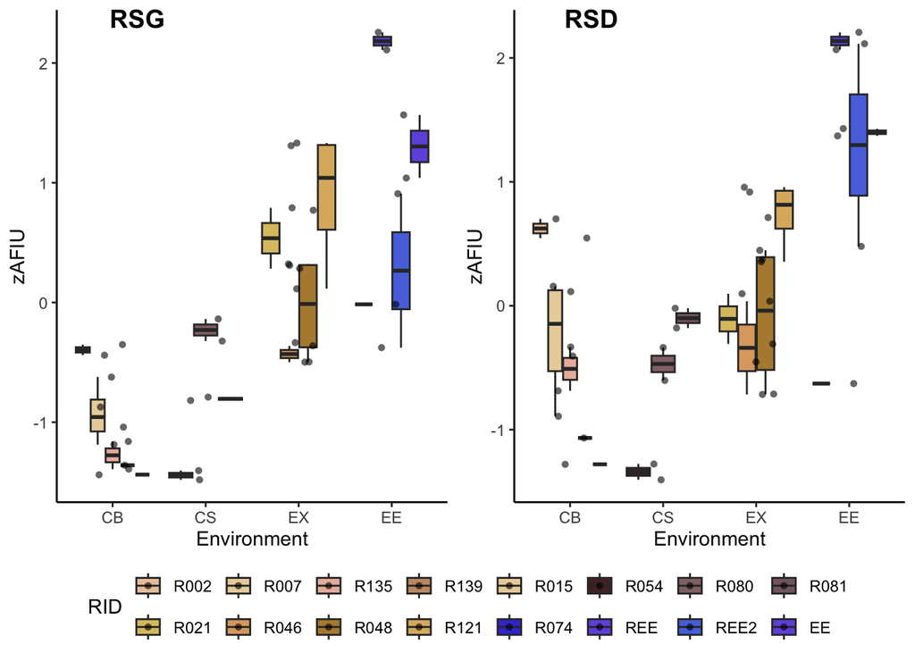

```r
axis_labels <- c("RSG","RSD")

Region1 <- subset(data_mean,BrainRegion == "RSG")
Region2 <- subset(data_mean,BrainRegion == "RSD")

breaks_vec <- c("CB","CS","EX","EE")
color <- colors_list[[1]]

Plot1 <- ggplot(Region1, aes(x = Environment , y = zAFIU, fill = RID)) +
  geom_boxplot(position = position_dodge(width = 0.8)) +
  geom_jitter(position = position_jitter(width = 0.2), shape = 16, alpha = 0.6) +
  scale_fill_manual(values = Color_RID_mapping) +
  theme_classic()+
  theme(legend.position = "bottom") + guides(fill = guide_legend(nrow = 2, byrow = TRUE))



Plot2<- ggplot(Region2, aes(x = Environment , y = zAFIU, fill = RID)) +
  geom_boxplot(position = position_dodge(width = 0.8)) +
  geom_jitter(position = position_jitter(width = 0.2), shape = 16, alpha = 0.6) +
  scale_fill_manual(values = Color_RID_mapping) +
  theme_classic()+
  theme(legend.position = "right")

prow  <- plot_grid(Plot1 + theme(legend.position="none")
            ,Plot2 + theme(legend.position="none")
            ,align = 'vh'
            ,labels = axis_labels
            ,hjust = -2
            ,nrow = 1)

  legend <- get_legend(
  Plot1 + theme(legend.box.margin = margin(0, 0, 0, 12)))

  plot_grid(prow,legend,rel_heights  = c(6,1),nrow = 2)
```

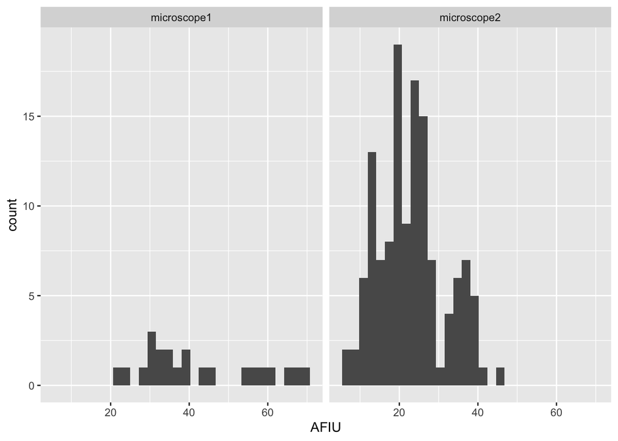

```r
ggplot(data, aes(x = AFIU)) +
  geom_histogram() +
  facet_wrap(~microscope)
```

### Plot by Region mean

This graph groups the Individuals together and clearly shows the differences on group level.

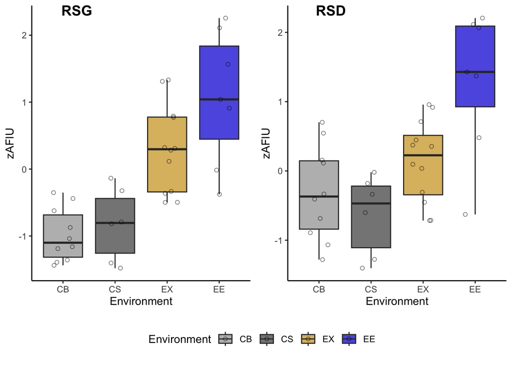

```r
axis_labels <- c("RSG","RSD")

Region1 <- subset(data_mean,BrainRegion == "RSG")
Region2 <- subset(data_mean,BrainRegion == "RSD")

breaks_vec <- c("CB","CS","EX","EE")
color <- colors_list[[1]]

Plot1 <- ggplot(Region1,aes(Environment,zAFIU,fill = Environment)) +
  geom_boxplot() +
  scale_fill_manual(breaks = breaks_vec,
                    values = color)+
  geom_jitter(shape = 1,alpha = 0.5,width = .2) +
  theme_classic()+
  theme(legend.position = "bottom")



Plot2<- ggplot(Region2,aes(Environment,zAFIU,fill = Environment)) +
  geom_boxplot() +
    scale_fill_manual(breaks = breaks_vec,
                    values = color)+
  geom_jitter(shape = 1,alpha = 0.5,width = .2) +
  theme_classic()

prow  <- plot_grid(Plot1 + theme(legend.position="none")
            ,Plot2 + theme(legend.position="none")
            ,align = 'vh'
            ,labels = axis_labels
            ,hjust = -2
            ,nrow = 1)

  legend <- get_legend(
  Plot1 + theme(legend.box.margin = margin(0, 0, 0, 12)))

  plot_grid(prow,legend,rel_heights  = c(3,.5),nrow = 2)
```

### Boxplot by Hemipshere mean

We were also interested in lateralization effects, thus this graph shows the two regions and the the values of each hemisphere.

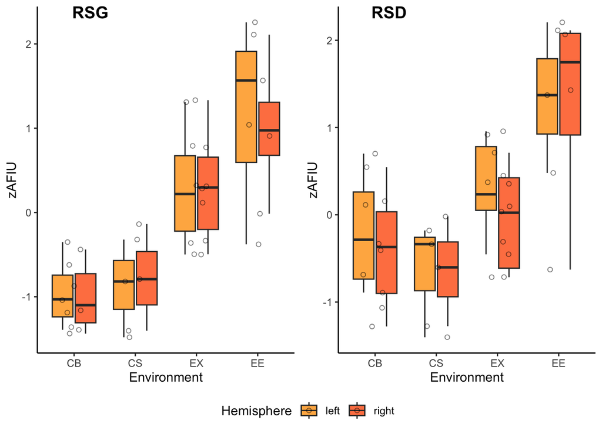

```r
axis_labels <- c("RSG","RSD")

Region1 <- subset(data_mean,BrainRegion == "RSG")
Region2 <- subset(data_mean,BrainRegion == "RSD")

breaks_vec <- c("left","right")
color <- colors_list[[2]]

Plot1 <- ggplot(Region1,aes(Environment,zAFIU,fill = Hemisphere)) +
  geom_boxplot() +
  scale_fill_manual(breaks = breaks_vec,
                    values = color)+
  geom_jitter(shape = 1,alpha = 0.5,width = .2) +
  theme_classic()+
  theme(legend.position = "top")



Plot2<- ggplot(Region2,aes(Environment,zAFIU,fill = Hemisphere)) +
  geom_boxplot() +
    scale_fill_manual(breaks = breaks_vec,
                    values = color)+
  geom_jitter(shape = 1,alpha = 0.5,width = .2) +
  theme_classic()

prow  <- plot_grid(Plot1 + theme(legend.position="none")
            ,Plot2 + theme(legend.position="none")
            ,align = 'vh'
            ,labels = axis_labels
            ,hjust = -2
            ,nrow = 1)

  legend <- get_legend(
  Plot1 + theme(legend.box.margin = margin(0, 0, 0, 12)))

  plot_grid(prow,legend,rel_heights = c(10,1),nrow = 2)
```

# Statistical Analysis

## ANOVA

The ANOVA showed significant group differences, but no effect of the hemisphere.

```r
### Regions
RSG <- subset(data,BrainRegion == "RSG")
RSD <- subset(data,BrainRegion == "RSD")

RSG_mean <- subset(data_mean,BrainRegion == "RSG")
RSD_mean <- subset(data_mean,BrainRegion == "RSD")
```

### RSG

```r
ANOVA <- aov(zAFIU ~ Environment + Hemisphere, data = RSG)

summary(ANOVA)
```

```
##             Df Sum Sq Mean Sq F value   Pr(>F)
## Environment  3  35.21   11.74  18.069 8.16e-09 ***
## Hemisphere   1   0.05    0.05   0.078    0.781
## Residuals   71  46.12    0.65
## ---
## Signif. codes:  0 '***' 0.001 '**' 0.01 '*' 0.05 '.' 0.1 ' ' 1
```

```r
TukeyHSD(ANOVA)
```

```
##   Tukey multiple comparisons of means
##     95% family-wise confidence level
##
## Fit: aov(formula = zAFIU ~ Environment + Hemisphere, data = RSG)
##
## $Environment
##            diff        lwr       upr     p adj
## CS-CB 0.2459109 -0.4245987 0.9164205 0.7697192
## EX-CB 1.0503655  0.4020889 1.6986421 0.0003499
## EE-CB 1.8917499  1.1363528 2.6471470 0.0000000
## EX-CS 0.8044546  0.1561780 1.4527312 0.0089561
## EE-CS 1.6458391  0.8904420 2.4012362 0.0000013
## EE-EX 0.8413845  0.1056507 1.5771182 0.0186075
##
## $Hemisphere
##                   diff        lwr      upr    p adj
## right-left -0.05124765 -0.4204233 0.317928 0.782744
```

### RSD

```r
ANOVA <- aov(zAFIU ~ Environment + Hemisphere, data = RSD)

summary(ANOVA)
```

```
##             Df Sum Sq Mean Sq F value   Pr(>F)
## Environment  3  24.11   8.037   13.37 5.19e-07 ***
## Hemisphere   1   0.93   0.925    1.54    0.219
## Residuals   71  42.67   0.601
## ---
## Signif. codes:  0 '***' 0.001 '**' 0.01 '*' 0.05 '.' 0.1 ' ' 1
```

```r
TukeyHSD(ANOVA)
```

```
##   Tukey multiple comparisons of means
##     95% family-wise confidence level
##
## Fit: aov(formula = zAFIU ~ Environment + Hemisphere, data = RSD)
##
## $Environment
##             diff         lwr       upr     p adj
## CS-CB -0.3988932 -1.04384754 0.2460612 0.3701512
## EX-CB  0.1271128 -0.49645589 0.7506815 0.9498871
## EE-CB  1.3144700  0.58786353 2.0410766 0.0000578
## EX-CS  0.5260060 -0.09756272 1.1495747 0.1279063
## EE-CS  1.7133632  0.98675670 2.4399697 0.0000002
## EE-EX  1.1873572  0.47966466 1.8950498 0.0002044
##
## $Hemisphere
##                  diff        lwr       upr     p adj
## right-left -0.2196375 -0.5747428 0.1354677 0.2215382
```

## LLM

```r
library(lmerTest)
lmer(AFIU ~ Environment + BrainRegion + Hemisphere + (1|microscope/RID),data = data) %>%
  summary()
```

```
## Linear mixed model fit by REML. t-tests use Satterthwaite's method [
## lmerModLmerTest]
## Formula: AFIU ~ Environment + BrainRegion + Hemisphere + (1 | microscope/RID)
##    Data: data
##
## REML criterion at convergence: 995.1
##
## Scaled residuals:
##      Min       1Q   Median       3Q      Max
## -2.29353 -0.47750 -0.05194  0.44247  3.02872
##
## Random effects:
##  Groups         Name        Variance Std.Dev.
##  RID:microscope (Intercept)  50.14    7.081
##  microscope     (Intercept) 169.21   13.008
##  Residual                    35.65    5.971
## Number of obs: 152, groups:  RID:microscope, 19; microscope, 2
##
## Fixed effects:
##                 Estimate Std. Error       df t value Pr(>|t|)
## (Intercept)      25.6370     9.7841   1.1588   2.620  0.20364
## EnvironmentCS     1.9305     5.4159  12.3138   0.356  0.72754
## EnvironmentEX     9.4788     4.3751  13.1966   2.167  0.04914 *
## EnvironmentEE    18.0689     4.9173  13.3746   3.675  0.00268 **
## BrainRegionRSG   -1.4120     0.9686 129.8814  -1.458  0.14730
## Hemisphereright  -0.1705     0.9975 132.0373  -0.171  0.86453
## ---
## Signif. codes:  0 '***' 0.001 '**' 0.01 '*' 0.05 '.' 0.1 ' ' 1
##
## Correlation of Fixed Effects:
##             (Intr) EnvrCS EnvrEX EnvrEE BrRRSG
## EnvirnmntCS -0.172
## EnvirnmntEX -0.234  0.417
## EnvirnmntEE -0.201  0.386  0.460
## BrainRgnRSG -0.049  0.000  0.000  0.000
## Hemsphrrght -0.066  0.037  0.027 -0.003  0.000
```

```r
data %>%
  filter(microscope == "microscope2") %>%
  with(lmer(AFIU ~ Environment + BrainRegion + Hemisphere + (1|RID))) %>%
    summary()
```

```
## Linear mixed model fit by REML. t-tests use Satterthwaite's method [
## lmerModLmerTest]
## Formula: AFIU ~ Environment + BrainRegion + Hemisphere + (1 | RID)
##
## REML criterion at convergence: 839.9
##
## Scaled residuals:
##      Min       1Q   Median       3Q      Max
## -2.22750 -0.48223 -0.04491  0.44380  2.91545
##
## Random effects:
##  Groups   Name        Variance Std.Dev.
##  RID      (Intercept) 20.07    4.480
##  Residual             38.06    6.169
## Number of obs: 130, groups:  RID, 14
##
## Fixed effects:
##                 Estimate Std. Error       df t value Pr(>|t|)
## (Intercept)      20.0463     2.7581  11.9823   7.268 9.98e-06 ***
## EnvironmentCS    -1.4076     3.8371   8.7103  -0.367   0.7225
## EnvironmentEX     5.5109     3.6175   9.3359   1.523   0.1608
## EnvironmentEE    10.7600     3.9529   9.7580   2.722   0.0219 *
## BrainRegionRSG   -1.3971     1.0821 113.3703  -1.291   0.1993
## Hemisphereright  -0.1061     1.1090 116.0250  -0.096   0.9240
## ---
## Signif. codes:  0 '***' 0.001 '**' 0.01 '*' 0.05 '.' 0.1 ' ' 1
##
## Correlation of Fixed Effects:
##             (Intr) EnvrCS EnvrEX EnvrEE BrRRSG
## EnvirnmntCS -0.660
## EnvirnmntEX -0.694  0.497
## EnvirnmntEE -0.624  0.453  0.481
## BrainRgnRSG -0.196  0.000  0.000  0.000
## Hemsphrrght -0.236  0.040  0.015 -0.032  0.000
```

# References

El-Sharkawey, Ayman. 2016. “Calculate the Corrected Total Cell Fluorescence (CTCF).”

# Appendix

## descriptives

```r
table(data$RID)
```

```
##
## R002 R007 R135 R139  CB1   CB R004 R015 R054 R080 R081 R116  CS1   CS R021 R046
##    8   24    4    2    0    0    0    2    8   22   10    0    0    0   12    6
## R048 R121  EX1   EX R074 R133  REE REE2  EE1   EE  EE2  EE3
##   16   12    0    0    4    0   12    6    0    4    0    0
```

## Plots

### Plots without mean of RIDs

#### Plots by RID

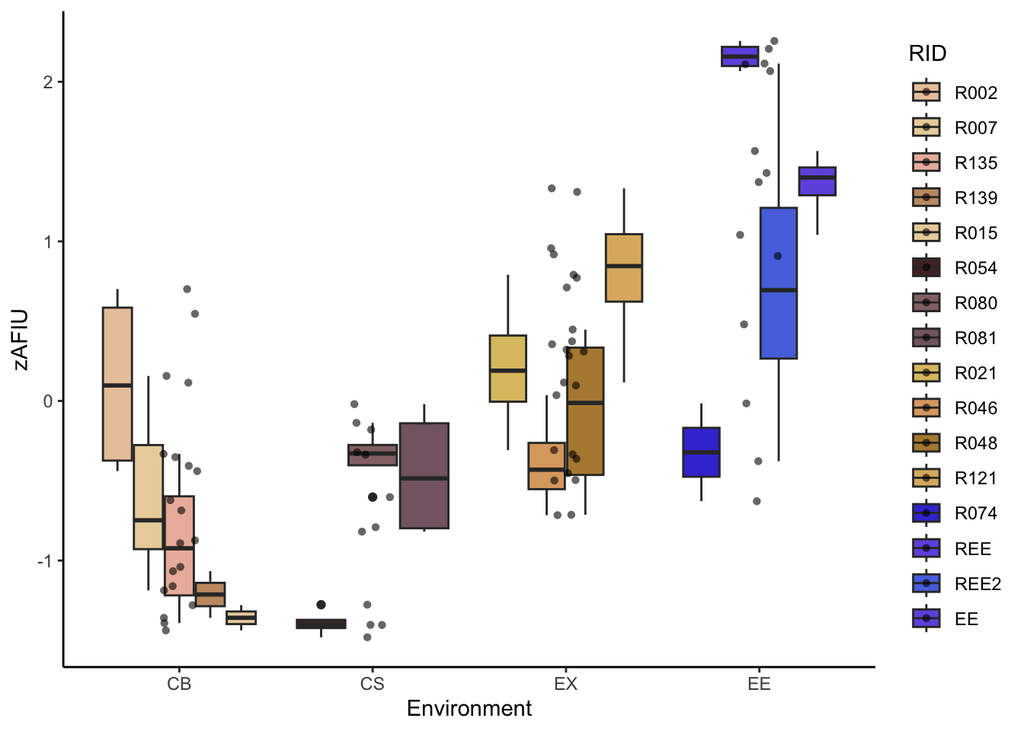

```r
ggplot(data_mean, aes(x = Environment , y = zAFIU, fill = RID)) +
  geom_boxplot(position = position_dodge(width = 0.8)) +
  geom_jitter(position = position_jitter(width = 0.1), shape = 16, alpha = 0.6,
              aes(x = Environment , y = zAFIU, fill = RID)) +
  scale_fill_manual(values = Color_RID_mapping) +
  theme_classic()+
  theme(legend.position = "right")
```

#### Plots by RID by BrainRegion

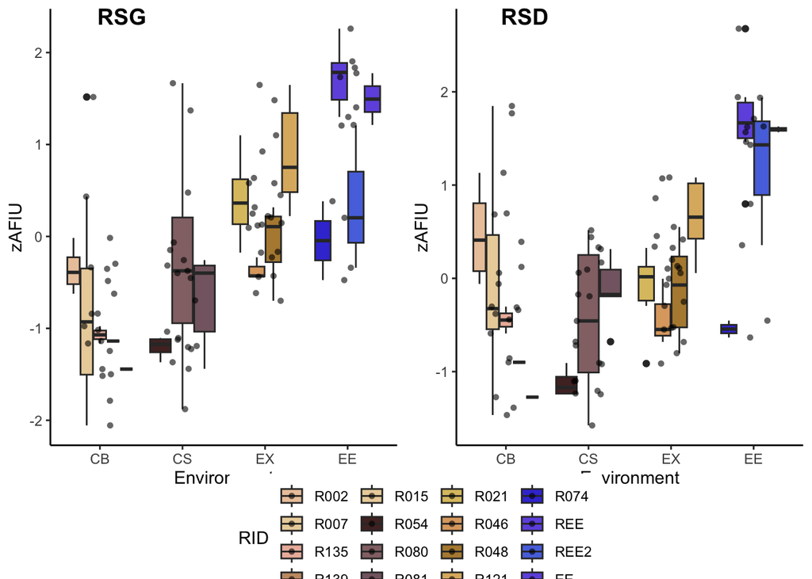

```r
axis_labels <- c("RSG","RSD")

Region1 <- subset(data,BrainRegion == "RSG")
Region2 <- subset(data,BrainRegion == "RSD")

breaks_vec <- c("CB","CS","EX","EE")
color <- colors_list[[1]]

Plot1 <- ggplot(Region1, aes(x = Environment , y = zAFIU, fill = RID)) +
  geom_boxplot(position = position_dodge(width = 0.8)) +
  geom_jitter(position = position_jitter(width = 0.2), shape = 16, alpha = 0.6) +
  scale_fill_manual(values = Color_RID_mapping) +
  theme_classic()+
  theme(legend.position = "bottom")



Plot2<- ggplot(Region2, aes(x = Environment , y = zAFIU, fill = RID)) +
  geom_boxplot(position = position_dodge(width = 0.8)) +
  geom_jitter(position = position_jitter(width = 0.2), shape = 16, alpha = 0.6) +
  scale_fill_manual(values = Color_RID_mapping) +
  theme_classic()+
  theme(legend.position = "right")

prow  <- plot_grid(Plot1 + theme(legend.position="none")
            ,Plot2 + theme(legend.position="none")
            ,align = 'vh'
            ,labels = axis_labels
            ,hjust = -2
            ,nrow = 1)

  legend <- get_legend(
  Plot1 + theme(legend.box.margin = margin(0, 0, 0, 12)))

  plot_grid(prow,legend,rel_heights  = c(3,.5),nrow = 2)
```

#### Plot by Environment

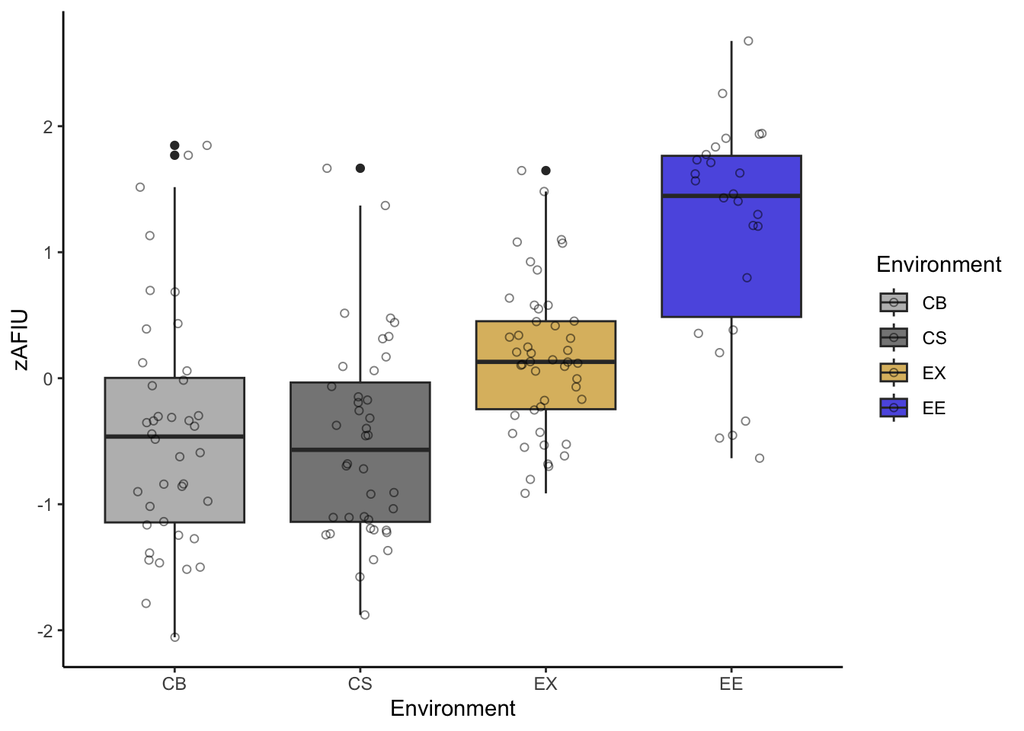

```r
ggplot(data,aes(Environment,zAFIU,fill = Environment)) +
  geom_boxplot() +
  geom_jitter(shape = 1,alpha = 0.5,width = .2)+
  scale_fill_manual(breaks = c("CB","CS","EX","EE"),
                    values =  colors_list[[1]])+
  theme_classic()
```

#### Plot by Region

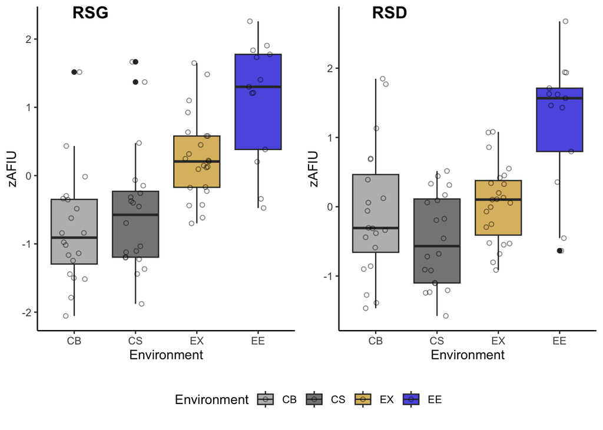

```r
axis_labels <- c("RSG","RSD")

Region1 <- subset(data,BrainRegion == "RSG")
Region2 <- subset(data,BrainRegion == "RSD")

breaks_vec <- c("CB","CS","EX","EE")
color <- colors_list[[1]]

Plot1 <- ggplot(Region1,aes(Environment,zAFIU,fill = Environment)) +
  geom_boxplot() +
  scale_fill_manual(breaks = breaks_vec,
                    values = color)+
  geom_jitter(shape = 1,alpha = 0.5,width = .2) +
  theme_classic()+
  theme(legend.position = "bottom")



Plot2<- ggplot(Region2,aes(Environment,zAFIU,fill = Environment)) +
  geom_boxplot() +
    scale_fill_manual(breaks = breaks_vec,
                    values = color)+
  geom_jitter(shape = 1,alpha = 0.5,width = .2) +
  theme_classic()

prow  <- plot_grid(Plot1 + theme(legend.position="none")
            ,Plot2 + theme(legend.position="none")
            ,align = 'vh'
            ,labels = axis_labels
            ,hjust = -2
            ,nrow = 1)

  legend <- get_legend(
  Plot1 + theme(legend.box.margin = margin(0, 0, 0, 12)))

  plot_grid(prow,legend,rel_heights  = c(3,.5),nrow = 2)
```

#### Boxplot by Hemipshere

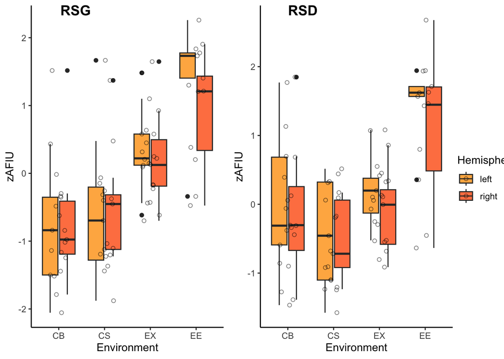

```r
axis_labels <- c("RSG","RSD")

Region1 <- subset(data,BrainRegion == "RSG")
Region2 <- subset(data,BrainRegion == "RSD")

breaks_vec <- c("left","right")
color <- colors_list[[2]]

Plot1 <- ggplot(Region1,aes(Environment,zAFIU,fill = Hemisphere)) +
  geom_boxplot() +
  scale_fill_manual(breaks = breaks_vec,
                    values = color)+
  geom_jitter(shape = 1,alpha = 0.5,width = .2) +
  theme_classic()+
  theme(legend.position = "right")



Plot2<- ggplot(Region2,aes(Environment,zAFIU,fill = Hemisphere)) +
  geom_boxplot() +
    scale_fill_manual(breaks = breaks_vec,
                    values = color)+
  geom_jitter(shape = 1,alpha = 0.5,width = .2) +
  theme_classic()

prow  <- plot_grid(Plot1 + theme(legend.position="none")
            ,Plot2 + theme(legend.position="none")
            ,align = 'vh'
            ,labels = axis_labels
            ,hjust = -2
            ,nrow = 1)

  legend <- get_legend(
  Plot1 + theme(legend.box.margin = margin(0, 0, 0, 12)))

  plot_grid(prow,legend,rel_widths = c(10,1),nrow = 1)
```

### Plots by median (mean)

#### Plots by RID

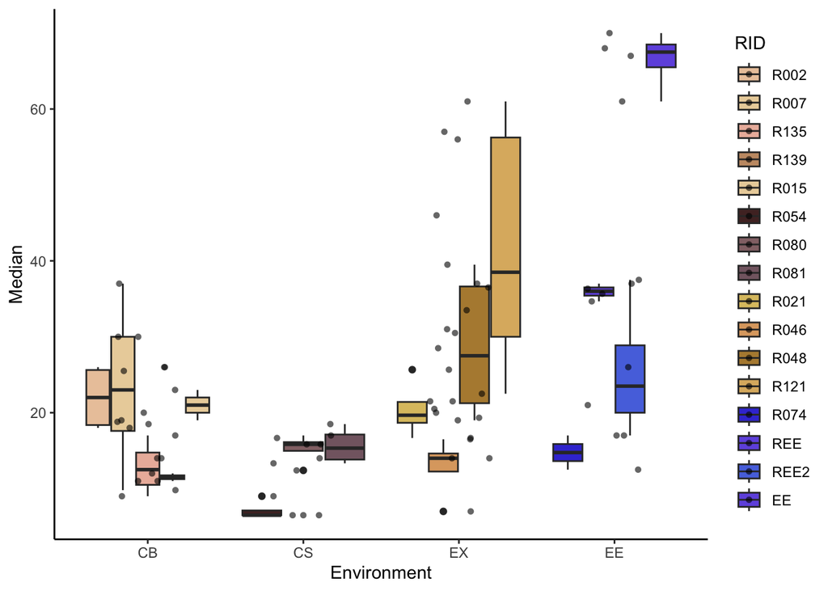

```r
ggplot(data_mean, aes(x = Environment , y = Median, fill = RID)) +
  geom_boxplot(position = position_dodge(width = 0.8)) +
  geom_jitter(position = position_jitter(width = 0.2), shape = 16, alpha = 0.6) +
  scale_fill_manual(values = Color_RID_mapping) +
  theme_classic()+
  theme(legend.position = "right")
```

#### Plots by RID by BrainRegion

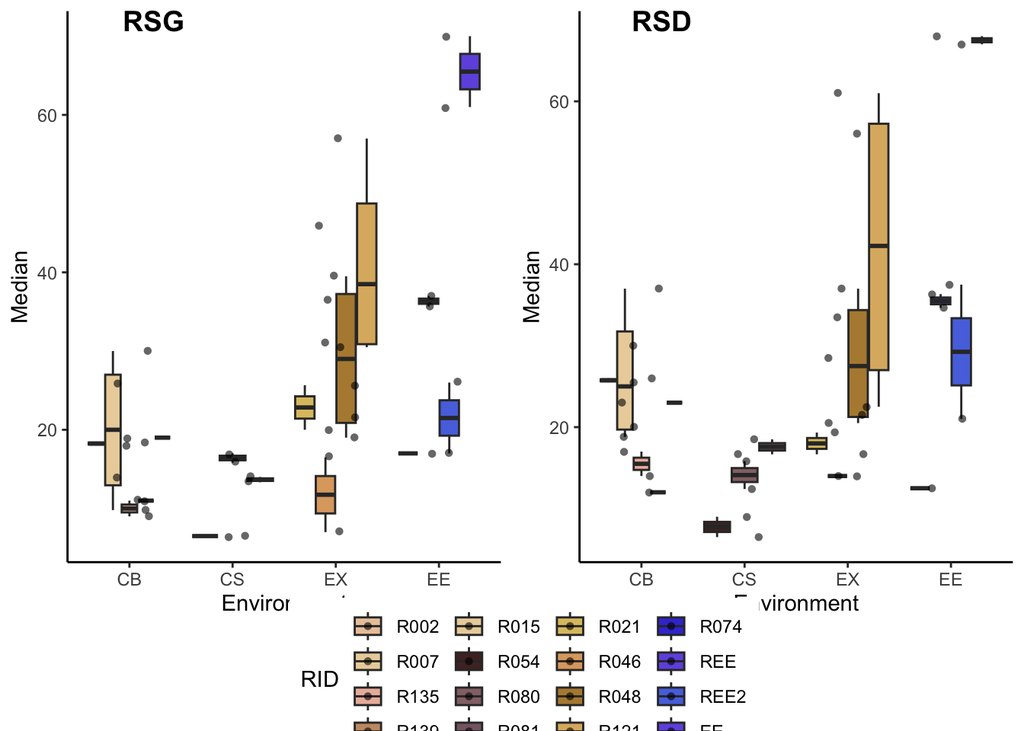

```r
axis_labels <- c("RSG","RSD")

Region1 <- subset(data_mean,BrainRegion == "RSG")
Region2 <- subset(data_mean,BrainRegion == "RSD")

breaks_vec <- c("CB","CS","EX","EE")
color <- colors_list[[1]]

Plot1 <- ggplot(Region1, aes(x = Environment , y = Median, fill = RID)) +
  geom_boxplot(position = position_dodge(width = 0.8)) +
  geom_jitter(position = position_jitter(width = 0.2), shape = 16, alpha = 0.6) +
  scale_fill_manual(values = Color_RID_mapping) +
  theme_classic()+
  theme(legend.position = "bottom")



Plot2<- ggplot(Region2, aes(x = Environment , y = Median, fill = RID)) +
  geom_boxplot(position = position_dodge(width = 0.8)) +
  geom_jitter(position = position_jitter(width = 0.2), shape = 16, alpha = 0.6) +
  scale_fill_manual(values = Color_RID_mapping) +
  theme_classic()+
  theme(legend.position = "right")

prow  <- plot_grid(Plot1 + theme(legend.position="none")
            ,Plot2 + theme(legend.position="none")
            ,align = 'vh'
            ,labels = axis_labels
            ,hjust = -2
            ,nrow = 1)

  legend <- get_legend(
  Plot1 + theme(legend.box.margin = margin(0, 0, 0, 12)))

  plot_grid(prow,legend,rel_heights  = c(3,.5),nrow = 2)
```

#### Plot by Environment mean

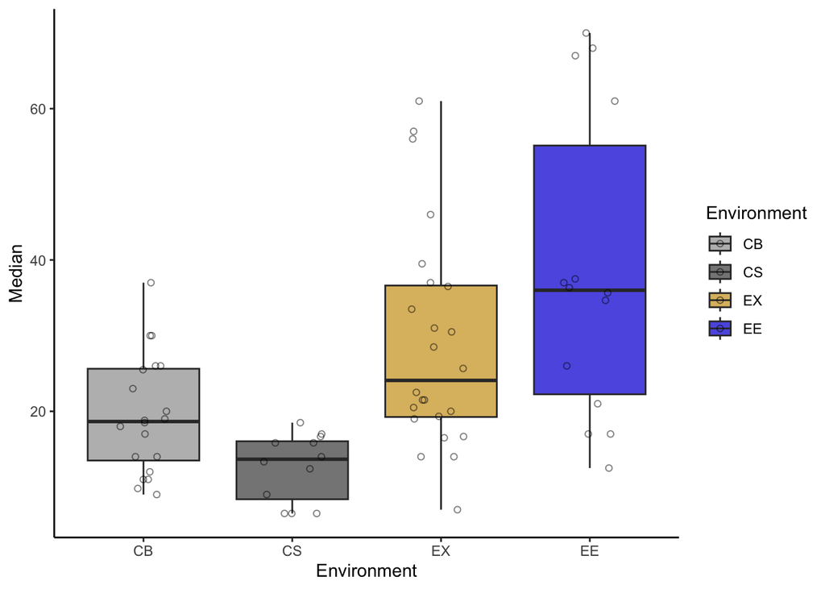

```r
ggplot(data_mean,aes(Environment,Median,fill = Environment)) +
  geom_boxplot() +
  geom_jitter(shape = 1,alpha = 0.5,width = .2)+
  scale_fill_manual(breaks = c("CB","CS","EX","EE"),
                    values =  colors_list[[1]])+
  theme_classic()
```

#### Plot by Region mean

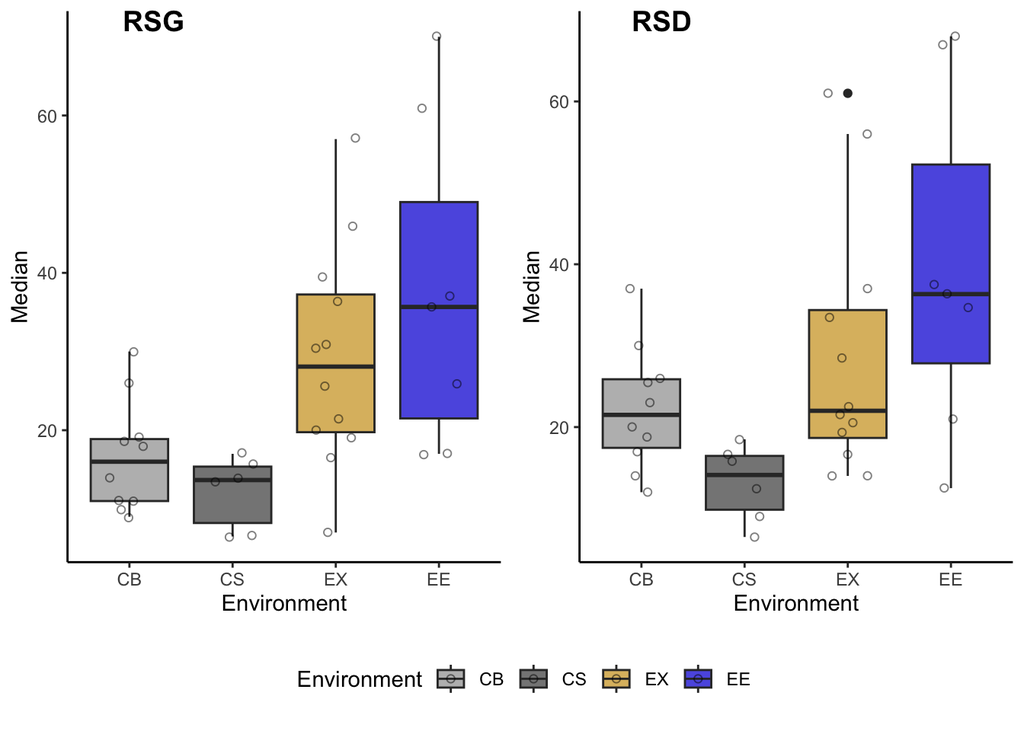

```r
axis_labels <- c("RSG","RSD")

Region1 <- subset(data_mean,BrainRegion == "RSG")
Region2 <- subset(data_mean,BrainRegion == "RSD")

breaks_vec <- c("CB","CS","EX","EE")
color <- colors_list[[1]]

Plot1 <- ggplot(Region1,aes(Environment,Median,fill = Environment)) +
  geom_boxplot() +
  scale_fill_manual(breaks = breaks_vec,
                    values = color)+
  geom_jitter(shape = 1,alpha = 0.5,width = .2) +
  theme_classic()+
  theme(legend.position = "bottom")



Plot2<- ggplot(Region2,aes(Environment,Median,fill = Environment)) +
  geom_boxplot() +
    scale_fill_manual(breaks = breaks_vec,
                    values = color)+
  geom_jitter(shape = 1,alpha = 0.5,width = .2) +
  theme_classic()

prow  <- plot_grid(Plot1 + theme(legend.position="none")
            ,Plot2 + theme(legend.position="none")
            ,align = 'vh'
            ,labels = axis_labels
            ,hjust = -2
            ,nrow = 1)

  legend <- get_legend(
  Plot1 + theme(legend.box.margin = margin(0, 0, 0, 12)))

  plot_grid(prow,legend,rel_heights  = c(3,.5),nrow = 2)
```

#### Boxplot by Hemipshere mean

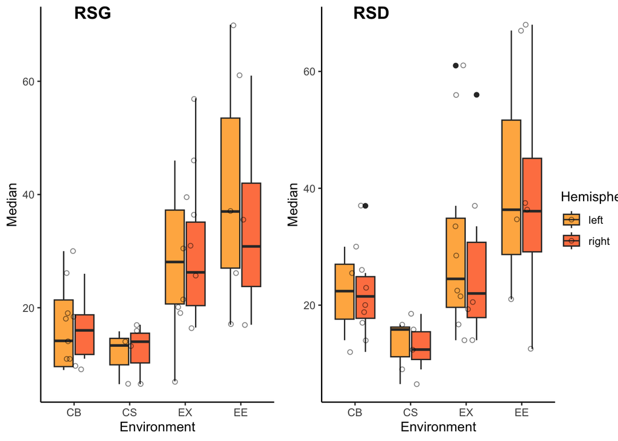

```r
axis_labels <- c("RSG","RSD")

Region1 <- subset(data_mean,BrainRegion == "RSG")
Region2 <- subset(data_mean,BrainRegion == "RSD")

breaks_vec <- c("left","right")
color <- colors_list[[2]]

Plot1 <- ggplot(Region1,aes(Environment,Median,fill = Hemisphere)) +
  geom_boxplot() +
  scale_fill_manual(breaks = breaks_vec,
                    values = color)+
  geom_jitter(shape = 1,alpha = 0.5,width = .2) +
  theme_classic()+
  theme(legend.position = "right")



Plot2<- ggplot(Region2,aes(Environment,Median,fill = Hemisphere)) +
  geom_boxplot() +
    scale_fill_manual(breaks = breaks_vec,
                    values = color)+
  geom_jitter(shape = 1,alpha = 0.5,width = .2) +
  theme_classic()

prow  <- plot_grid(Plot1 + theme(legend.position="none")
            ,Plot2 + theme(legend.position="none")
            ,align = 'vh'
            ,labels = axis_labels
            ,hjust = -2
            ,nrow = 1)

  legend <- get_legend(
  Plot1 + theme(legend.box.margin = margin(0, 0, 0, 12)))

  plot_grid(prow,legend,rel_widths = c(10,1),nrow = 1)
```